# Can We Predict Google App Rating?(Linear Regression)

## **Section 1 - Introduction:**

### **Hypothesis Question** : Can we Predict Google App Rating based on App Reviews and App Total Number of Installs Or Is their any relationship between App Rating,App Reviews and App Total Number of Installs ?

#### **Description Of Data Set:**

#### Link: https://www.kaggle.com/lava18/google-play-store-apps

#### Data created by : Lavanya Gupta.

#### Description Of Data:

This dataset includes Gooele Playstore App data.This all apps are those which we usually store into our phone.This information is scraped from the Google Play Store. Purpose behind scrapping data was actionable insights can be drawn for developers to work on and capture the Android market.

#### Structure of Data:

#### Total Number Of Columns : 13

#### Total Number of Rows : 10841

#### Column Names:

1. App: Name of Application.(charater)
2. Category: Under Which category Application comes.(Ctegorical) – For Example:
   - ART_AND_DESIGN
   - GAME
   - COMIC
   - BUSINESS
   - SPORTS
   - SOCIAL.. Likewise
3. Rating: out of 5 how many ratings it got(Numeric)
4. Reviews: Total Number of reviews it got(Numeric)
5. Size: dowaload size of app in MB(Numeric)
6. Installs: Total Number of Installations (Numeric)
7. Type: Application is Free or Paid(Categorical)
8. Price: If App is paid than price is stored here(Numeric)
9. Content Rating: app content rating given by whom(Categorical) – For Example:
   - Adults Only 18+
   - Everyone
   - Everyone 10+..likewise
10. Genres: Under which genre application comes(Categorical) – For Example:
    - Action
    - Adventure
    - Casio
    - Beauty.. likewise
11. Last Updated: Datetime on which application was updated.(Date)
12. Current Ver: lastet version of application(Character)
13. Android Ver: Minimum Andriod Version Required for installing App.(Charater)

#### Loadind Required Libraries

```r
library(ggplot2)
library(tidyverse)
library(dplyr)
library(lubridate)
library(here)
```

### **General Overview of Data**

#### Reading Dataset

```r
google_app <- read_csv(here("Data", "googleplaystore.csv"))
```

#### First Five Records of Dataset

```r
head(google_app)
```

| App | Category | Rating | Reviews | Size | Installs | Type | Price | Content Rating | Genres | Last Updated | Current Ver | Android Ver |
| --- | --- | --- | --- | --- | --- | --- | --- | --- | --- | --- | --- | --- |
| Photo Editor & Candy Camera & Grid & ScrapBook | ART_AND_DESIGN | 4.1 | 159 | 19M | 10,000+ | Free | 0 | Everyone | Art & Design | January 7, 2018 | 1.0.0 | 4.0.3 and up |
| Coloring book moana | ART_AND_DESIGN | 3.9 | 967 | 14M | 500,000+ | Free | 0 | Everyone | Art & Design;Pretend Play | January 15, 2018 | 2.0.0 | 4.0.3 and up |
| U Launcher Lite – FREE Live Cool Themes, Hide Apps | ART_AND_DESIGN | 4.7 | 87510 | 8.7M | 5,000,000+ | Free | 0 | Everyone | Art & Design | August 1, 2018 | 1.2.4 | 4.0.3 and up |
| Sketch - Draw & Paint | ART_AND_DESIGN | 4.5 | 215644 | 25M | 50,000,000+ | Free | 0 | Teen | Art & Design | June 8, 2018 | Varies with device | 4.2 and up |
| Pixel Draw - Number Art Coloring Book | ART_AND_DESIGN | 4.3 | 967 | 2.8M | 100,000+ | Free | 0 | Everyone | Art & Design;Creativity | June 20, 2018 | 1.1 | 4.4 and up |
| Paper flowers instructions | ART_AND_DESIGN | 4.4 | 167 | 5.6M | 50,000+ | Free | 0 | Everyone | Art & Design | March 26, 2017 | 1 | 2.3 and up |

#### Shape of Dataset

```r
dim(google_app)
```

```
## [1] 10841    13
```

#### Glimpse of Dataset

```r
glimpse(google_app)
```

```
## Observations: 10,841
## Variables: 13
## $ App              <chr> "Photo Editor & Candy Camera & Grid & ScrapBook", "C…
## $ Category         <chr> "ART_AND_DESIGN", "ART_AND_DESIGN", "ART_AND_DESIGN"…
## $ Rating           <dbl> 4.1, 3.9, 4.7, 4.5, 4.3, 4.4, 3.8, 4.1, 4.4, 4.7, 4.…
## $ Reviews          <dbl> 159, 967, 87510, 215644, 967, 167, 178, 36815, 13791…
## $ Size             <chr> "19M", "14M", "8.7M", "25M", "2.8M", "5.6M", "19M", …
## $ Installs         <chr> "10,000+", "500,000+", "5,000,000+", "50,000,000+", …
## $ Type             <chr> "Free", "Free", "Free", "Free", "Free", "Free", "Fre…
## $ Price            <chr> "0", "0", "0", "0", "0", "0", "0", "0", "0", "0", "0…
## $ `Content Rating` <chr> "Everyone", "Everyone", "Everyone", "Teen", "Everyon…
## $ Genres           <chr> "Art & Design", "Art & Design;Pretend Play", "Art & …
## $ `Last Updated`   <chr> "January 7, 2018", "January 15, 2018", "August 1, 20…
## $ `Current Ver`    <chr> "1.0.0", "2.0.0", "1.2.4", "Varies with device", "1.…
## $ `Android Ver`    <chr> "4.0.3 and up", "4.0.3 and up", "4.0.3 and up", "4.2…
```

#### Summary of Dataset

```r
summary(google_app)
```

```
##      App              Category             Rating          Reviews
##  Length:10841       Length:10841       Min.   : 1.000   Min.   :       0
##  Class :character   Class :character   1st Qu.: 4.000   1st Qu.:      38
##  Mode  :character   Mode  :character   Median : 4.300   Median :    2094
##                                        Mean   : 4.193   Mean   :  444153
##                                        3rd Qu.: 4.500   3rd Qu.:   54776
##                                        Max.   :19.000   Max.   :78158306
##                                        NA's   :1474     NA's   :1
##      Size             Installs             Type              Price
##  Length:10841       Length:10841       Length:10841       Length:10841
##  Class :character   Class :character   Class :character   Class :character
##  Mode  :character   Mode  :character   Mode  :character   Mode  :character
##
##
##
##
##  Content Rating        Genres          Last Updated       Current Ver
##  Length:10841       Length:10841       Length:10841       Length:10841
##  Class :character   Class :character   Class :character   Class :character
##  Mode  :character   Mode  :character   Mode  :character   Mode  :character
##
##
##
##
##  Android Ver
##  Length:10841
##  Class :character
##  Mode  :character
##
##
##
##
```

#### Couting Null Values in Each column

```r
colSums(is.na(google_app))
```

```
##            App       Category         Rating        Reviews           Size
##              0              0           1474              1              0
##       Installs           Type          Price Content Rating         Genres
##              0              0              0              1              0
##   Last Updated    Current Ver    Android Ver
##              0              1              1
```

> **END OF SECTION 1**

## **Section 2 - Data analysis plan:**

### To Prove our hypothesis we will use **Raitng as Response Variable and Reviews, Installs as Explanatory Variables.**

### **(1). Data Cleaning**

#### Observations:

- Based upon above overview of our datset we got to know that our main variables which we will use for our main hypothesis analysis have some problems like Rating variable have 1474 Na’s value, Installs variable have ‘+’ symbol as well as it is in charater form and Reviews variables is having 1 Na’s.
- Apart From our main Analysis variables other varibale are having issues like Size column is having size in MB and KB as well as it is in form of character,Price variable is also in character form and contains ‘$’ symbol and Last updated variable contains date but it is in charater form.
- other variables like current ver,content rating and Android ver is having 1 Na’s each.

#### Steps For Cleaning:

- We will remove special symbols like ‘$’ from price,‘+’,‘,’ from installs,‘M’ and ‘k’ from size also will convert all sizes into MB.
- Rating and Reviews variables is having Na’s we will impute all those values by mean values of respective columns values.
- Also will convert Install,Price,size variables into numeric,Last Updated variable into date and Category,Type,Content Rating, Genres into factor as they are categorical variable.

#### Applying Data Cleaning

```r
#Removing Special Symbols from Price and installs
google_app$Price <- gsub('[$]', '', google_app$Price)
google_app$Installs <- gsub("\\+","", as.character(google_app$Installs))


#Converting Price and Install into numerical
google_app$Price <- as.numeric(google_app$Price)
google_app$Installs <- as.integer(gsub(",", "", google_app$Installs))
#Converting Category,Type,Genres into Factor
google_app$Category <- as.factor(google_app$Category)
google_app$Type <- as.factor(google_app$Type)
google_app$`Content Rating` <- as.factor(google_app$`Content Rating`)
google_app$Genres <- as.factor(google_app$Genres)

#Removing Special Symbols from Size Column and converting all size into MB
size_in_m <- google_app[grep('M', google_app$Size),]$Size #Removing all M symbol
size_in_m <- gsub('M', '', size_in_m) # Removing all M symbol
size_in_m <- as.numeric(size_in_m) #converting to numeric

size_in_k <- google_app[grep('k', google_app$Size),]$Size #Removing all K symbol
size_in_k <- gsub('k', '', size_in_k) #Removing all K symbol
size_in_k <- as.numeric(size_in_k)/1024 #converting to numeric as well as from Kilobytes to megabytes.

#creating a new variable and storing all cleanned values into new variable.
google_app$all_size_in_m = NA
google_app[grep('k', google_app$Size),]$all_size_in_m <- size_in_k
google_app[grep('M', google_app$Size),]$all_size_in_m <- size_in_m

#Removing Old Size Variable
google_app$Size <- NULL


#Converting Laste Updated Column into Date
google_app$`Last Updated` <- mdy(google_app$`Last Updated`)
google_app$date <- date(google_app$`Last Updated`)

#Removing  column Last Updated From Dataset
google_app$`Last Updated` <- NULL

#Imputing Rating and Reviews Na's values with mean
google_app$Rating[is.na(google_app$Rating)] <- round(mean(google_app$Rating, na.rm = TRUE))
google_app$Reviews[is.na(google_app$Reviews)] <- round(mean(google_app$Reviews, na.rm = TRUE))
google_app$Installs[is.na(google_app$Installs)] <- round(mean(google_app$Installs, na.rm = TRUE))
```

#### glimpse View after Data Cleaning

- As we can see all special symbols has been removed from Price,Size and Install column and converted into numeric.
- Category,Type,Content Ratingand Genres column has been converted to factor.
- All size are now in one measure in MB.
- Last updated Column has now converted into Date.
- Rating, Reviews and Installs null values are imputed with mean.

```r
glimpse(google_app)
```

```
## Observations: 10,841
## Variables: 13
## $ App              <chr> "Photo Editor & Candy Camera & Grid & ScrapBook", "C…
## $ Category         <fct> ART_AND_DESIGN, ART_AND_DESIGN, ART_AND_DESIGN, ART_…
## $ Rating           <dbl> 4.1, 3.9, 4.7, 4.5, 4.3, 4.4, 3.8, 4.1, 4.4, 4.7, 4.…
## $ Reviews          <dbl> 159, 967, 87510, 215644, 967, 167, 178, 36815, 13791…
## $ Installs         <dbl> 1e+04, 5e+05, 5e+06, 5e+07, 1e+05, 5e+04, 5e+04, 1e+…
## $ Type             <fct> Free, Free, Free, Free, Free, Free, Free, Free, Free…
## $ Price            <dbl> 0, 0, 0, 0, 0, 0, 0, 0, 0, 0, 0, 0, 0, 0, 0, 0, 0, 0…
## $ `Content Rating` <fct> Everyone, Everyone, Everyone, Teen, Everyone, Everyo…
## $ Genres           <fct> Art & Design, Art & Design;Pretend Play, Art & Desig…
## $ `Current Ver`    <chr> "1.0.0", "2.0.0", "1.2.4", "Varies with device", "1.…
## $ `Android Ver`    <chr> "4.0.3 and up", "4.0.3 and up", "4.0.3 and up", "4.2…
## $ all_size_in_m    <dbl> 19.0, 14.0, 8.7, 25.0, 2.8, 5.6, 19.0, 29.0, 33.0, 3…
## $ date             <date> 2018-01-07, 2018-01-15, 2018-08-01, 2018-06-08, 201…
```

#### Number of Null Values in all varibales

- Here as we can see our main analysis variables are not having Na values.
- other Columns are having few Na values but we can ignore that as we are not going to use it for Main analysis.

```r
colSums(is.na(google_app))
```

```
##            App       Category         Rating        Reviews       Installs
##              0              0              0              0              0
##           Type          Price Content Rating         Genres    Current Ver
##              0              1              1              0              1
##    Android Ver  all_size_in_m           date
##              1           1696              1
```

### **(2). Simple Data Exploration By visualizing**

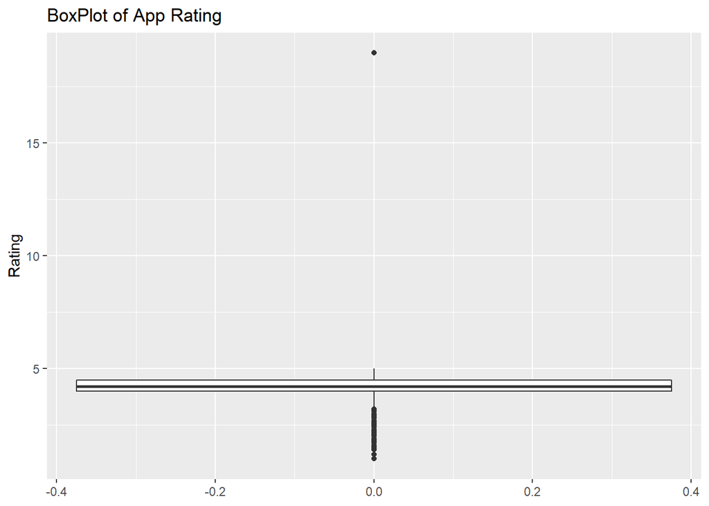

```r
ggplot(google_app,aes(y=Rating))+
  geom_boxplot()+
  ggtitle("BoxPlot of App Rating")+
  ylab("Rating")
```

— From Boxplot we can see most of App Rating is between number 3 to 5.

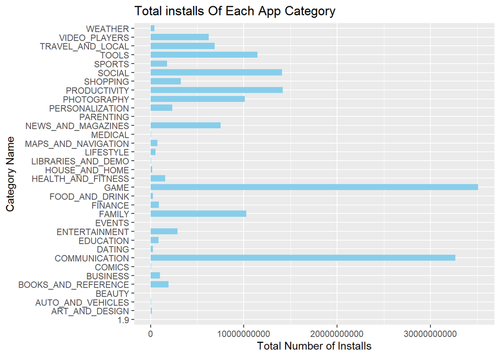

```r
options(scipen=999)
ggplot(google_app,aes(x=Category,y=Installs)) +
  geom_bar(stat = "identity",width = 0.7,fill="skyblue")+
  coord_flip()+
  ggtitle("Total installs Of Each App Category")+
  xlab("Category Name")+
  ylab("Total Number of Installs")
```

— We can see Out of all App category highest Game Category app is installed after that Communication Category app is highest number of time installed.

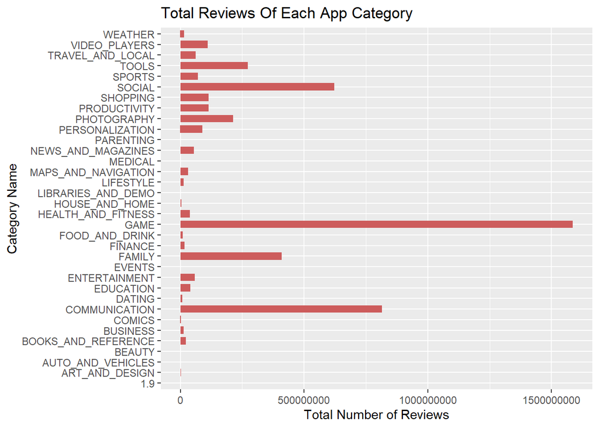

```r
ggplot(google_app,aes(x=Category,y=Reviews)) +
  geom_bar(stat = "identity",width = 0.7,fill="indianred")+
  coord_flip()+
  ggtitle("Total Reviews Of Each App Category")+
  xlab("Category Name")+
  ylab("Total Number of Reviews")
```

— We can see Out of all App category Game Category app is having highest number of reviews after that Communication Category app is highest number of Reviews.

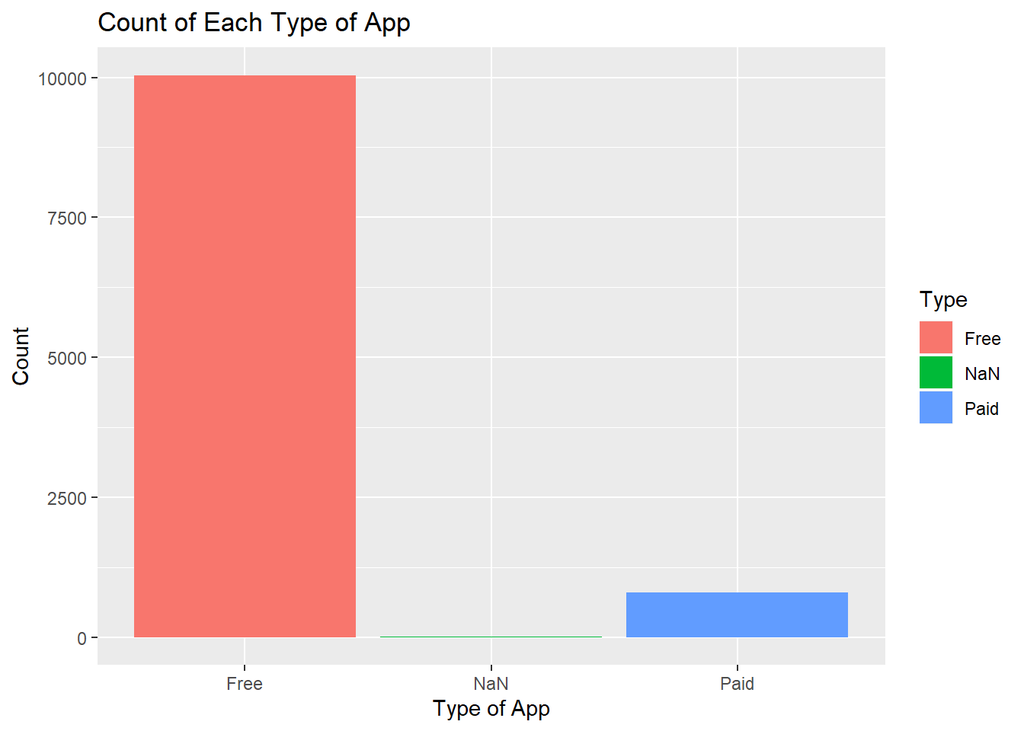

```r
 ggplot(google_app,aes(x=Type,fill=Type)) +
  geom_bar()+
  ggtitle("Count of Each Type of App")+
  xlab("Type of App")+
  ylab("Count")
```

— We can see here most of App are free very less app are paid.

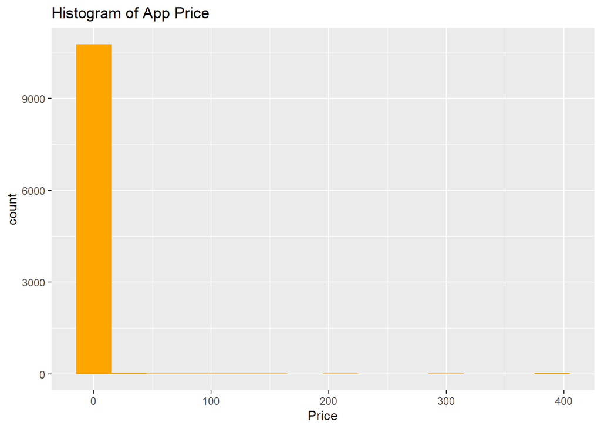

```r
ggplot(google_app,aes(x=Price))+
  geom_histogram(binwidth = 30,fill="orange")+
  ggtitle("Histogram of App Price")
```

— We can see most of App are having 0 dollar price which is true because most of App are free and those who are padi are mostly having price within 40 dollar.

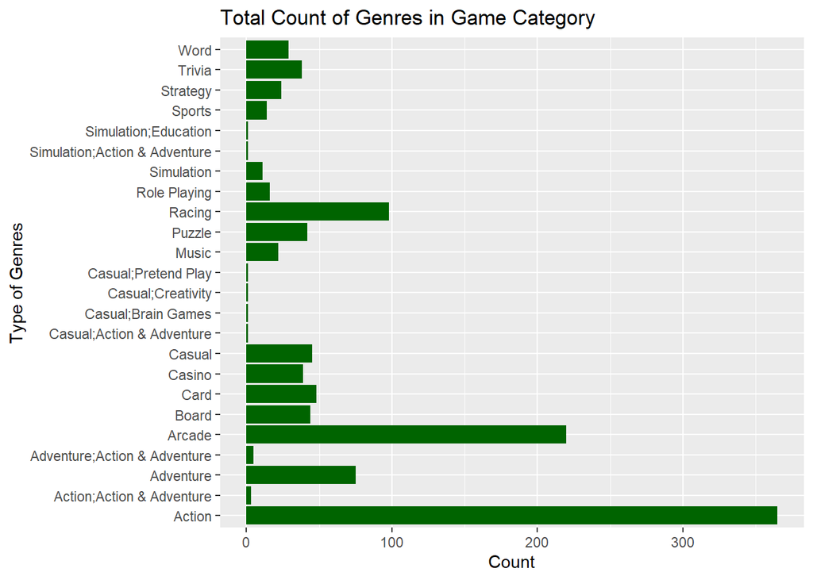

```r
google_app %>% filter(Category == "GAME") %>%
ggplot(aes(x=Genres))+
geom_bar(fill = "DarkGreen")+
ggtitle("Total Count of Genres in Game Category")+
xlab("Type of Genres")+
ylab("Count")+
coord_flip()
```

— From Game Category App most of them are Action Genres Type of App.

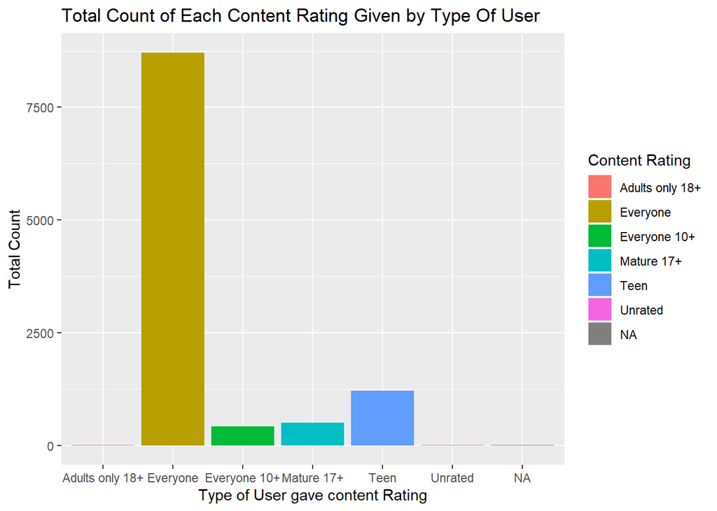

```r
ggplot(google_app,aes(x=`Content Rating`,fill = `Content Rating`))+
  geom_bar()+
  xlab("Type of User gave content Rating")+
  ylab("Total Count")+
  ggtitle("Total Count of Each Content Rating Given by Type Of User")
```

— Out of all type of User Most of Contetn Rating is given by Everyone.

### **(3). Exploratory data analysis**

- My Hypothesis is to predict App Rating which is my response variable based upon App Reviews and App total number of Installs which are my Explanatory variables.
- For doing exploratory data analysis we are going to explore our reponse variable App rating and both explanatory variable App reviews,App installs by applying Univariate analysis and Bivariate analysis.

#### Brief Description Of EDA variables

- Rating : It is numeric value ranges from 1 to 5.This rating is given by user to particular app 1 is minimum rating and 5 is maximum rating.
- Reviews : It is numeric value which is about total number of reviews given to App.
- Installs: It is numeric value which is about total number of Installs of each App.

#### Storing Explanatory and Response into one variable.

```r
google_eda <- google_app %>% select(Rating,Reviews,Installs)
```

#### Glimpse of Data

```r
glimpse(google_eda)
```

```
## Observations: 10,841
## Variables: 3
## $ Rating   <dbl> 4.1, 3.9, 4.7, 4.5, 4.3, 4.4, 3.8, 4.1, 4.4, 4.7, 4.4, 4.4, …
## $ Reviews  <dbl> 159, 967, 87510, 215644, 967, 167, 178, 36815, 13791, 121, 1…
## $ Installs <dbl> 10000, 500000, 5000000, 50000000, 100000, 50000, 50000, 1000…
```

#### Summary of Data

```r
summary(google_eda)
```

```
##      Rating          Reviews            Installs
##  Min.   : 1.000   Min.   :       0   Min.   :         0
##  1st Qu.: 4.000   1st Qu.:      38   1st Qu.:      1000
##  Median : 4.200   Median :    2094   Median :    100000
##  Mean   : 4.167   Mean   :  444153   Mean   :  15464339
##  3rd Qu.: 4.500   3rd Qu.:   54798   3rd Qu.:   5000000
##  Max.   :19.000   Max.   :78158306   Max.   :1000000000
```

#### Checking Null Values

```r
colSums(is.na(google_eda))
```

```
##   Rating  Reviews Installs
##        0        0        0
```

### **Univariate Analysis of Rating(Response Variable)**

#### Visualizing Distribution of Rating

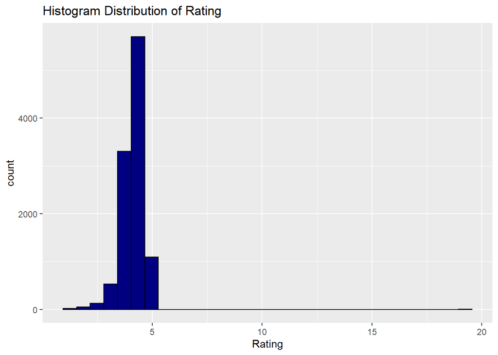

```r
ggplot(google_eda,aes(x=Rating))+
  geom_histogram(fill="navy blue",col="black")+
  ggtitle("Histogram Distribution of Rating")+
  xlab("Rating")
```

— From above graph we can see most of rating is between 3 to 5. — Here we have not passed binwidth first we will pass different binwidth to check any changes in plot than we will calculate best binwidth based upon their range.

#### Applying Different Binwidth

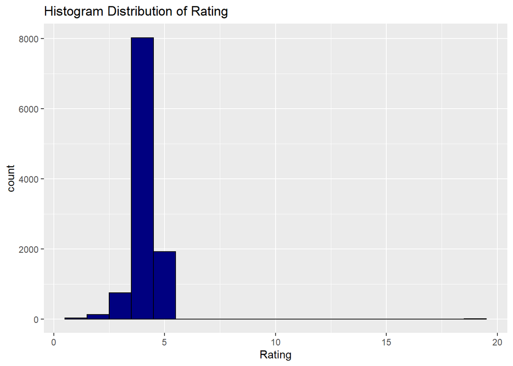

```r
ggplot(google_eda,aes(x=Rating))+
  geom_histogram(fill="navy blue",col="black",binwidth = 1)+
  ggtitle("Histogram Distribution of Rating")+
  xlab("Rating")
```

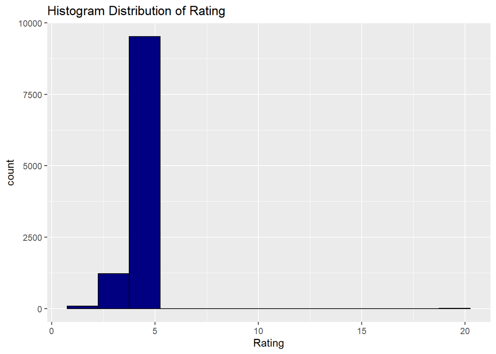

```r
ggplot(google_eda,aes(x=Rating))+
  geom_histogram(fill="navy blue",col="black",binwidth = 1.5)+
  ggtitle("Histogram Distribution of Rating")+
  xlab("Rating")
```

#### Calculating binwidth

```r
print(max(google_eda$Rating))
```

```
## [1] 19
```

```r
print(min(google_eda$Rating))
```

```
## [1] 1
```

```r
rating_range <- max(google_eda$Rating) - min(google_eda$Rating)
rating_range <- rating_range / 30
rating_range
```

```
## [1] 0.6
```

#### plotting with Calculated binwidth

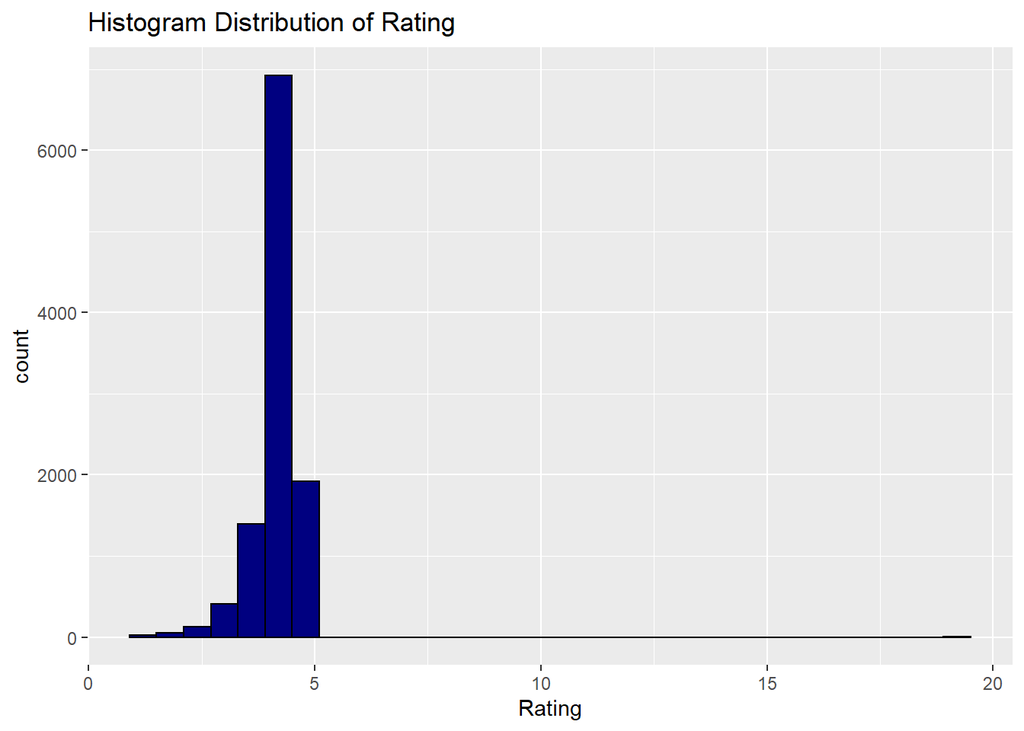

```r
ggplot(google_eda,aes(x=Rating))+
  geom_histogram(fill="navy blue",col="black",binwidth = 0.6)+
  ggtitle("Histogram Distribution of Rating")+
  xlab("Rating")
```

— Even after calculating binwidth graph shows us Rating beyond 5 which suggest that there is an outlier in our dataset we should remove that than try to plot histogram it should give use proper result.

#### Checking Outlier

```r
google_eda %>% filter(Rating > 5)
```

| Rating | Reviews | Installs |
| --- | --- | --- |
| 19 | 444153 | 15464339 |

— We found one value greater than 5 which is outlier because we know that Rating can not be greater than 5.We should remove this value.

#### Removing Outlier

```r
google_eda <- google_eda[google_eda$Rating!= 19,]
```

#### Ploting Rating After Removal of Outlier

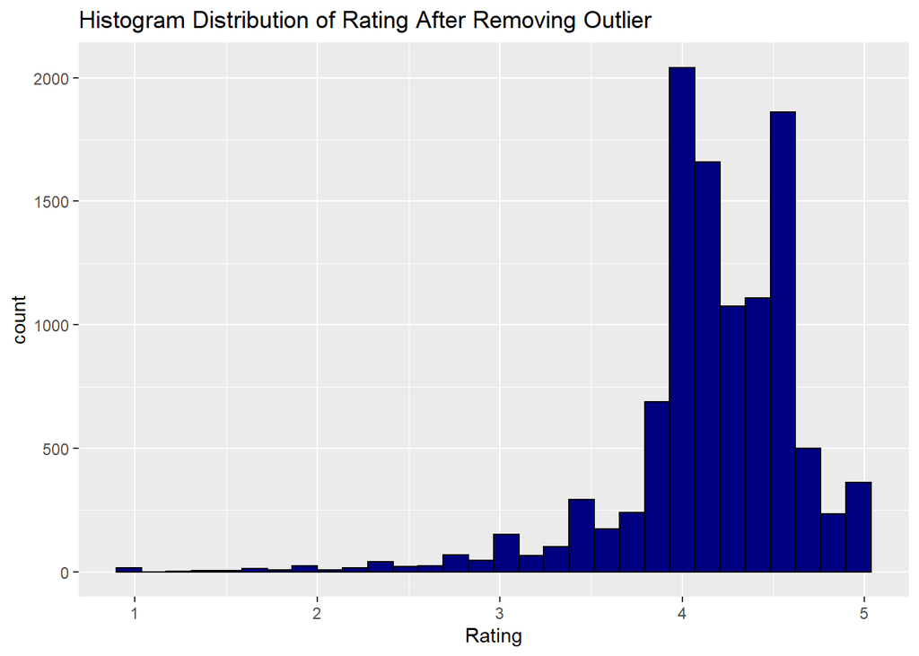

```r
ggplot(google_eda,aes(x=Rating))+
  geom_histogram(fill="navy blue",col="black")+
  ggtitle("Histogram Distribution of Rating After Removing Outlier")+
  xlab("Rating")
```

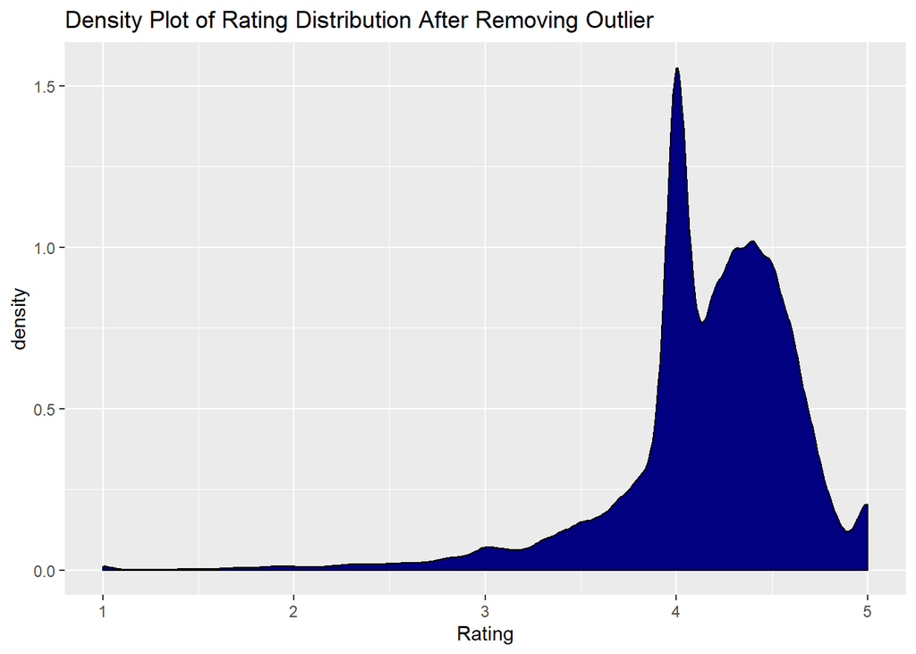

```r
ggplot(google_eda,aes(x=Rating))+
  geom_density(fill="navy blue",col="black")+
  ggtitle("Density Plot of Rating Distribution After Removing Outlier")+
  xlab("Rating")
```

— After Removing Outlier we can see most of Rating are between 4-5.

#### Checking For Transformation Need

- Transformation is generally applied to Normalize our data but our Rating variable is already skewed because we have removed outliers from it even from log10 and sqrt plot we can see that their is no need for transformation of Rating Variable.

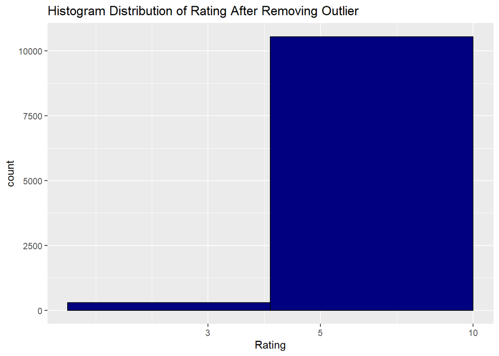

```r
ggplot(google_eda,aes(x=Rating + 1))+
  geom_histogram(fill="navy blue",col="black",binwidth = 0.4)+
  ggtitle("Histogram Distribution of Rating After Removing Outlier")+
  xlab("Rating")+
  scale_x_log10()
```

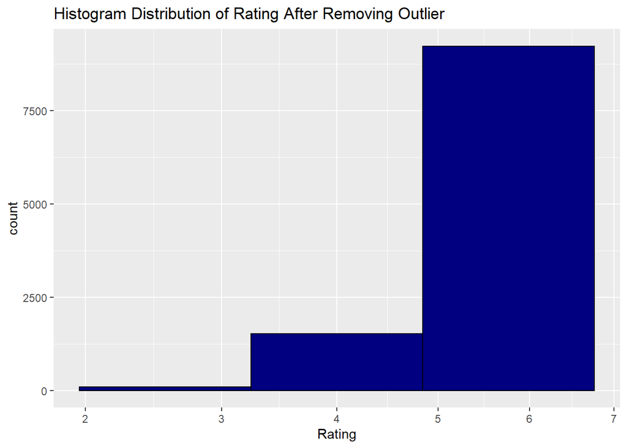

```r
ggplot(google_eda,aes(x=Rating + 1))+
  geom_histogram(fill="navy blue",col="black",binwidth = 0.4)+
  ggtitle("Histogram Distribution of Rating After Removing Outlier")+
  xlab("Rating")+
  scale_x_sqrt()
```

#### Finding Skewness and Modality of Rating

```r
summary(google_eda$Rating)
```

```
##    Min. 1st Qu.  Median    Mean 3rd Qu.    Max.
##   1.000   4.000   4.200   4.166   4.500   5.000
```

#### Finding Measure of Spread and Meausre of Central Tendency

- As we have seen before our data is highly skewed in that case it is always better to choose **median** as measure of central tendency beacause it helps us to find center of data.
- Here Median is greater than mean which prooves skewness in our dataset as well as we can detect any outlier’s our dataset using medain.Median is also most robust measure to outliers.
- In case of measure of spread **IQR** is always best when our data is skewed.It is robust as well and it always help us to find percentage of observations that comes under specific distances from mean.

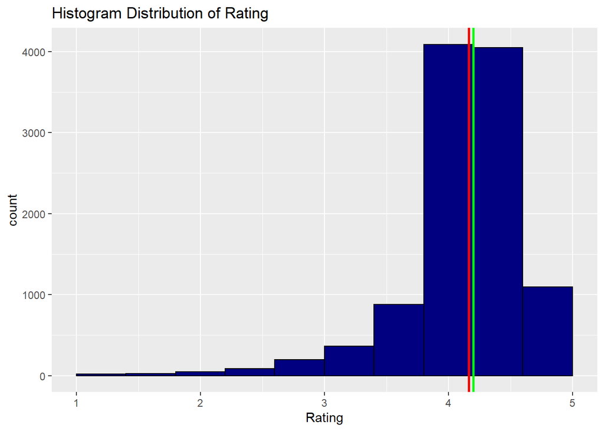

```r
ggplot(google_eda,aes(x = Rating)) +
   geom_histogram(fill="navy blue",col="black",binwidth =0.4)+
   geom_vline(aes(xintercept = mean(google_eda$Rating)), color = "red", linetype = "solid", size = 1) +
   geom_vline(aes(xintercept = median(google_eda$Rating)), color = "Green", linetype = "solid", size = 1) +
   ggtitle("Histogram Distribution of Rating")+
  xlab("Rating")
```

```r
IQR(google_eda$Rating)
```

```
## [1] 0.5
```

### **Univariate Analysis of Reviews(Explanatory Variable)**

#### Visualizing Distribution of Reviews

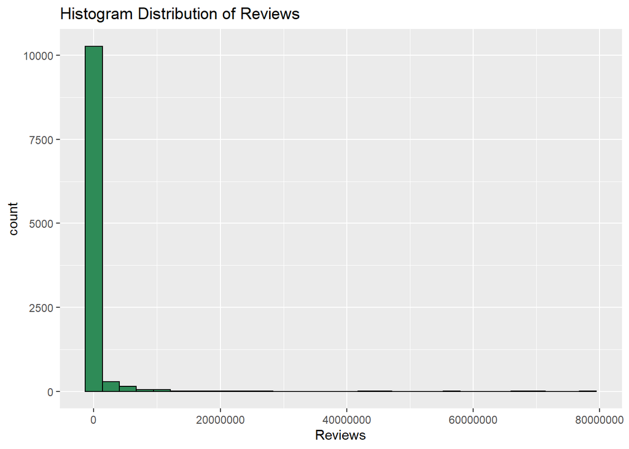

```r
ggplot(google_eda,aes(x=Reviews))+
  geom_histogram(fill="seagreen",col="black")+
  ggtitle("Histogram Distribution of Reviews")+
  xlab("Reviews")
```

— From histogram we can see that most of App reviews are under 20000000.

#### Calculating binwidth

```r
Reviews_range <- max(google_eda$Reviews) - min(google_eda$Reviews)
Reviews_range <- Reviews_range / 30
Reviews_range
```

```
## [1] 2605277
```

#### Applying Calculated binwidth to Histogram

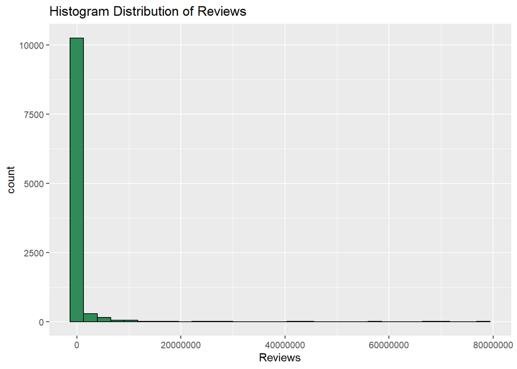

```r
ggplot(google_eda,aes(x=Reviews))+
  geom_histogram(fill="seagreen",col="black",binwidth = 2605277)+
  ggtitle("Histogram Distribution of Reviews")+
  xlab("Reviews")
```

#### Checking For Outlier

- From histogram we can see some points after 6,000,000 can be considered as outliers but in our dataset few of App is having Reviews more 2,000,000 such as like Facebook, Instagram, PUBG Mobile, Candy Crush,Clash of Clanes so by considering values beyond 6,000,000 as outliers is bias.We should keep all values which help up us to understad our data more betterly.
- Even we find one pattern that those App who have higher number of Reviews is having Higher number of Installs so this also suggests that their is not outlier in our Reviews variable.

```r
google_eda %>% filter(Reviews > 6000000)
```

| Rating | Reviews | Installs |
| --- | --- | --- |
| 4.0 | 56642847 | 1000000000 |
| 4.4 | 69119316 | 1000000000 |
| 4.3 | 9642995 | 1000000000 |
| 4.3 | 11334799 | 500000000 |
| 4.5 | 17712922 | 500000000 |
| 4.4 | 69119316 | 1000000000 |
| 4.0 | 56646578 | 1000000000 |
| 4.3 | 11334973 | 500000000 |
| 4.1 | 10484169 | 1000000000 |
| 4.2 | 10790289 | 500000000 |

[output cut: 170 more lines]

#### Checking For Transformation Need

- Transformation is generally applied to Normalize our data but our Reviews variable is already skewed and there is no outliers in it even from log10 and sqrt plot we can see that their is no need for transformation of Reviews Variable.

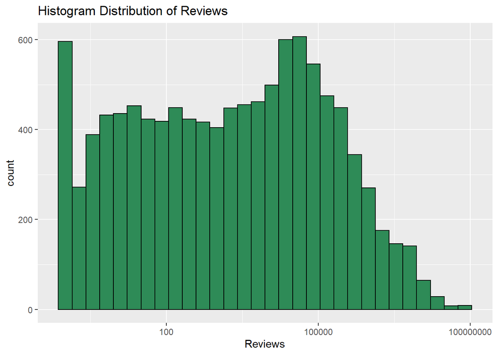

```r
ggplot(google_eda,aes(x=Reviews+ 1))+
  geom_histogram(fill="seagreen",col="black")+
  ggtitle("Histogram Distribution of Reviews")+
  xlab("Reviews")+
  scale_x_log10()
```

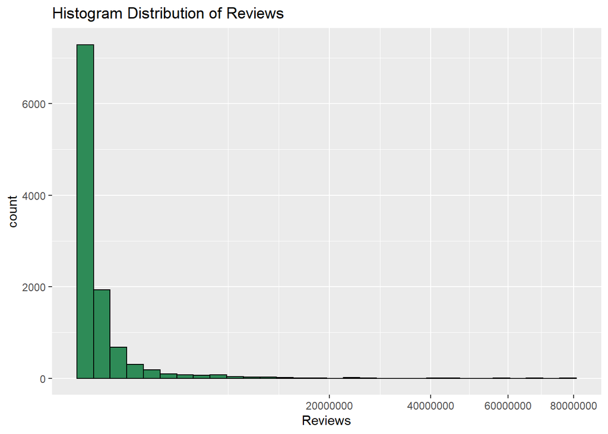

```r
ggplot(google_eda,aes(x=Reviews+ 1))+
  geom_histogram(fill="seagreen",col="black")+
  ggtitle("Histogram Distribution of Reviews")+
  xlab("Reviews")+
 scale_x_sqrt()
```

```r
summary(google_eda$Reviews)
```

```
##     Min.  1st Qu.   Median     Mean  3rd Qu.     Max.
##        0       38     2094   444153    54776 78158306
```

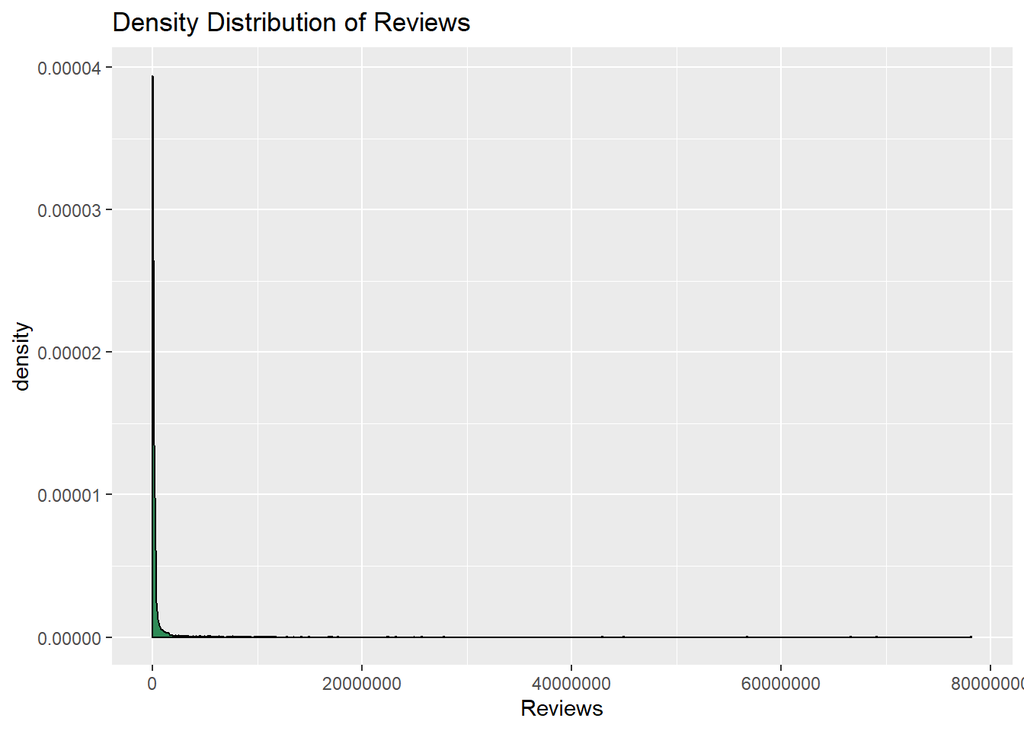

```r
ggplot(google_eda,aes(x=Reviews))+
  geom_density(fill="seagreen",col="black")+
  ggtitle("Density Distribution of Reviews")+
  xlab("Reviews")
```

#### Finding Measure of Spread and Meausre of Central Tendency

- As our data is highly skewed in that case it is always better to choose **median** as measure of central tendency beacause it helps us to find center of data.
- Here Mean is greater than Median which prooves skewness in our dataset as well as we can detect any outlier’s our dataset using medain.Median is also most robust measure to outliers.
- In case of measure of spread **IQR** is always best when our data is skewed.It is robust as well and it always help us to find percentage of observations that comes under specific distances from mean.

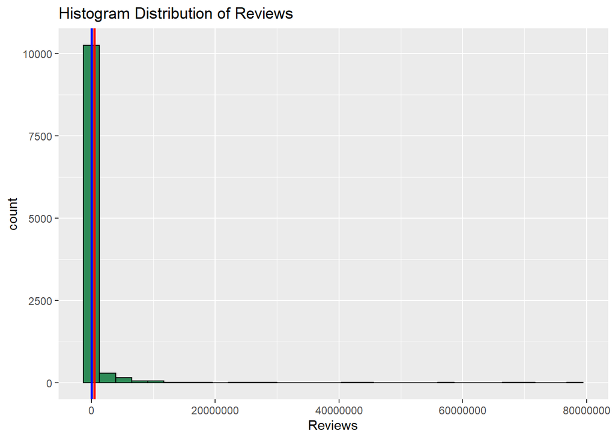

```r
ggplot(google_eda,aes(x = Reviews)) +
   geom_histogram(fill="seagreen",col="black",binwidth =2605277)+
   geom_vline(aes(xintercept = mean(google_eda$Reviews)), color = "red", linetype = "solid", size = 1) +
   geom_vline(aes(xintercept = median(google_eda$Reviews)), color = "Blue", linetype = "solid", size = 1) +
   ggtitle("Histogram Distribution of Reviews")+
  xlab("Reviews")
```

```r
IQR(google_eda$Reviews)
```

```
## [1] 54737.5
```

### **Univariate Analysis of Installs(Explanatory Variable)**

#### Visualizing Distribution of Installs

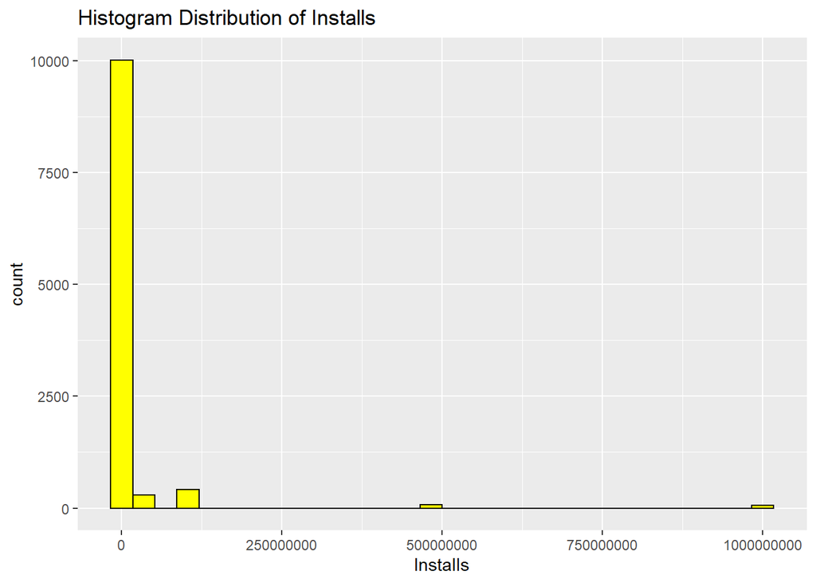

```r
ggplot(google_eda,aes(x=Installs))+
  geom_histogram(fill="yellow",col="black")+
  ggtitle("Histogram Distribution of Installs")+
  xlab("Installs")
```

— From histogram we can see that most of App Total Number of Installs are under 125,000,0000.

#### Calculating binwidth

```r
Install_range <- max(google_eda$Installs) - min(google_eda$Installs)
Install_range <- Install_range / 30
Install_range
```

```
## [1] 33333333
```

#### Applying Calculated binwidth to Histogram

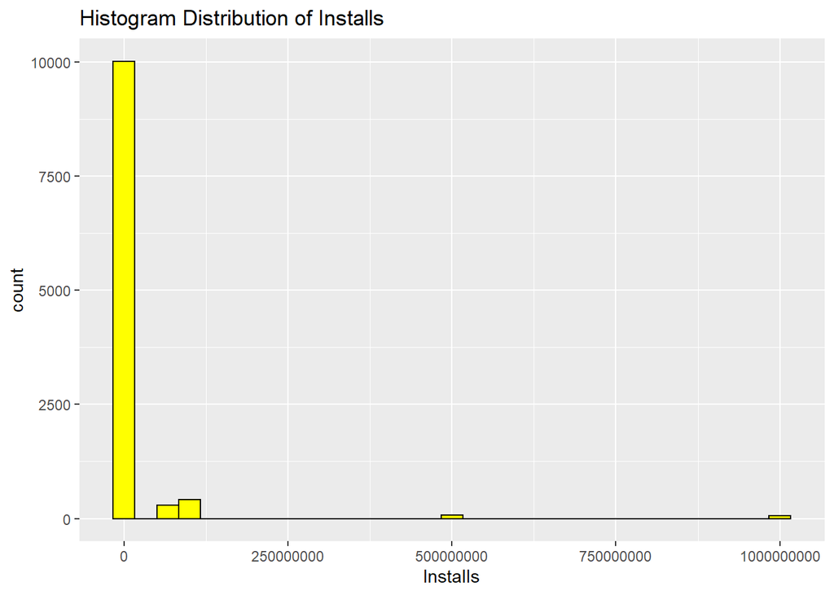

```r
ggplot(google_eda,aes(x=Installs))+
  geom_histogram(fill="yellow",col="black",binwidth = 33333333)+
  ggtitle("Histogram Distribution of Installs")+
  xlab("Installs")
```

— After applying Calculated binwidth their is not much change in our histogram.

#### Checking For Outlier

- From histogram we can see that values beyond 125,000,0000 could be outliers but that having total number of installs greater than that is might or mistake or error.
- On other when we cross check our self we found that Large famous App such as like Facebook, Google, Gmail, Google news, whatsapp, Google chrome, Instagram, Google+ this apps are having total number of installs in billions which is true because this apps are used by most of people around world.
- This highly Installed App are also having High number of Reviews.
- So according to that we should not remove those values from our dataset.

```r
google_eda %>% filter(Installs >= 1000000000)
```

| Rating | Reviews | Installs |
| --- | --- | --- |
| 3.9 | 1433233 | 1000000000 |
| 4.0 | 56642847 | 1000000000 |
| 4.4 | 69119316 | 1000000000 |
| 4.3 | 9642995 | 1000000000 |
| 4.3 | 4604324 | 1000000000 |
| 4.0 | 3419249 | 1000000000 |
| 4.4 | 69119316 | 1000000000 |
| 4.0 | 56646578 | 1000000000 |
| 4.0 | 3419433 | 1000000000 |
| 4.1 | 10484169 | 1000000000 |

[output cut: 48 more lines]

#### Checking For Transformation Need

- Transformation is generally applied to Normalize our data but our Installs variable is already skewed and there is no outliers in it even from log10 and sqrt plot we can see that their is no need for transformation of Reviews Variable.

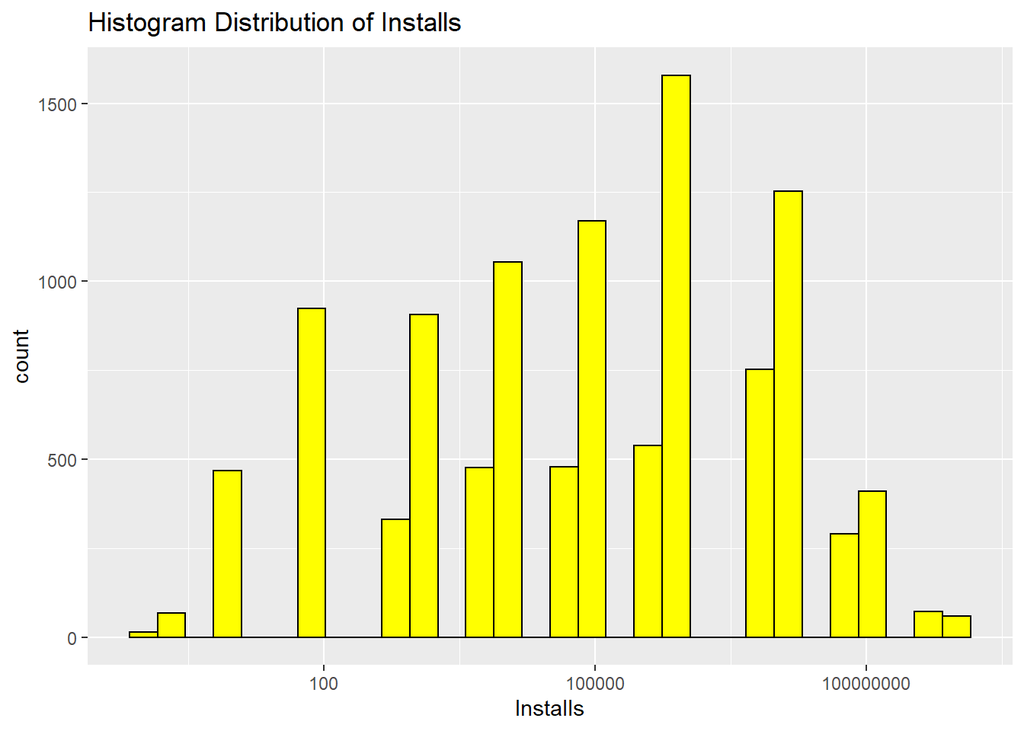

```r
ggplot(google_eda,aes(x=Installs +1))+
  geom_histogram(fill="yellow",col="black")+
  ggtitle("Histogram Distribution of Installs")+
  xlab("Installs")+
  scale_x_log10()
```

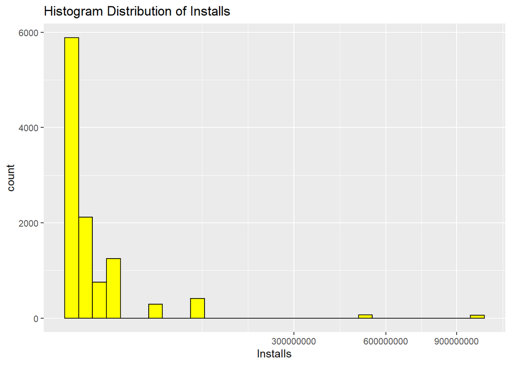

```r
ggplot(google_eda,aes(x=Installs+1))+
  geom_histogram(fill="yellow",col="black")+
  ggtitle("Histogram Distribution of Installs")+
  xlab("Installs") +
  scale_x_sqrt()
```

#### Finding Skewness and Modality of Installs

```r
summary(google_eda$Installs)
```

```
##       Min.    1st Qu.     Median       Mean    3rd Qu.       Max.
##          0       1000     100000   15464339    5000000 1000000000
```

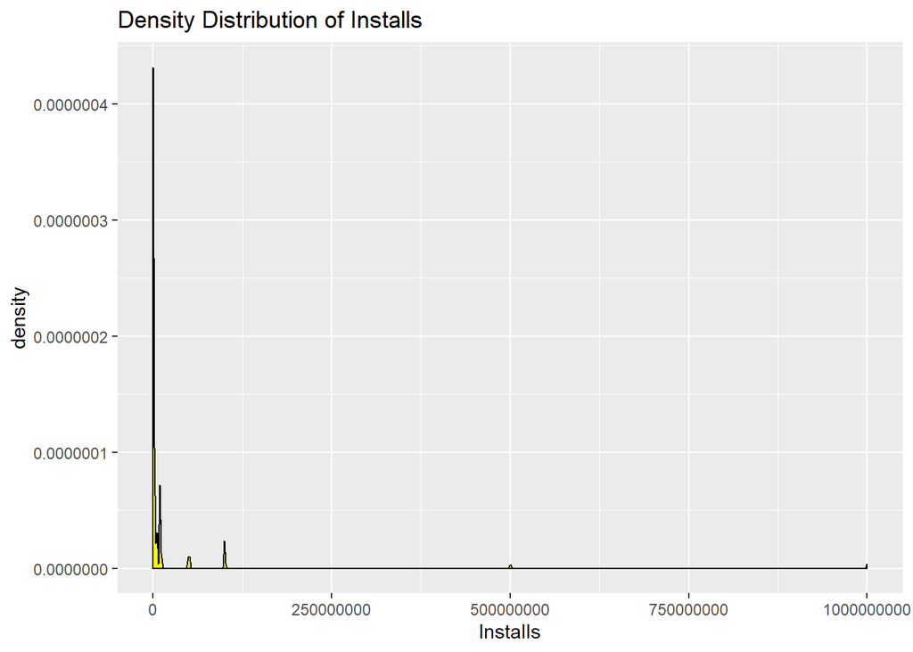

```r
ggplot(google_eda,aes(x=Installs))+
  geom_density(fill="yellow",col="black")+
  ggtitle("Density Distribution of Installs")+
  xlab("Installs")
```

#### Finding Measure of Spread and Meausre of Central Tendency

- As our data is highly skewed in that case it is always better to choose **median** as measure of central tendency beacause it helps us to find center of data.
- Here Mean is greater than Median which prooves skewness in our dataset as well as we can detect any outlier’s our dataset using medain.Median is also most robust measure to outliers.
- In case of measure of spread **IQR** is always best when our data is skewed.It is robust as well and it always help us to find percentage of observations that comes under specific distances from mean.

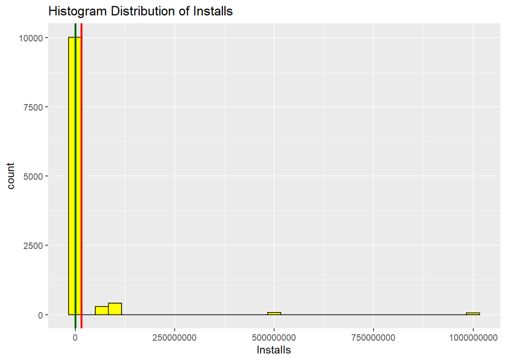

```r
ggplot(google_eda,aes(x = Installs)) +
   geom_histogram(fill="Yellow",col="black",binwidth =33333333)+
   geom_vline(aes(xintercept = mean(google_eda$Installs)), color = "red", linetype = "solid", size = 1) +
   geom_vline(aes(xintercept = median(google_eda$Installs)), color = "DarkGreen", linetype = "solid", size = 1) +
   ggtitle("Histogram Distribution of Installs")+
  xlab("Installs")
```

```r
IQR(google_eda$Installs)
```

```
## [1] 4999000
```

### **Bivariate Analysis of Rating(Response Variable) and Reviews(Explanatory Variable)**

#### Creating a Plot to Visualize Relationship

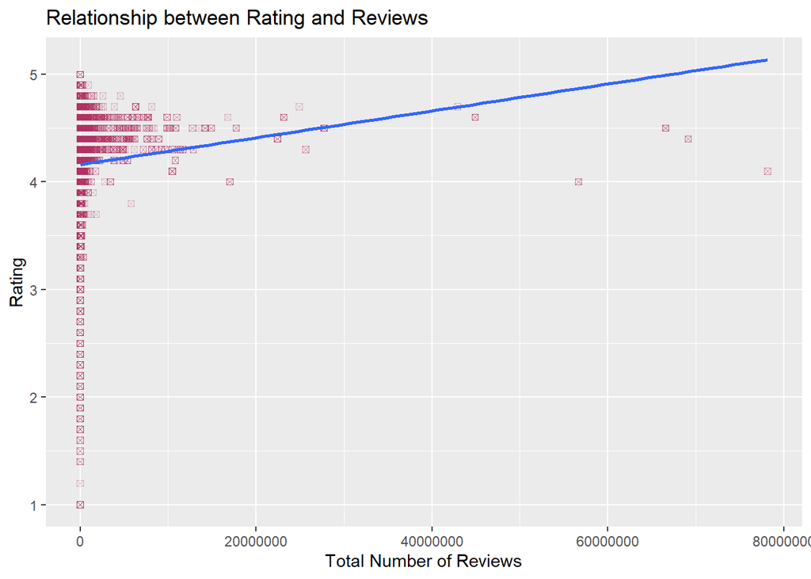

```r
ggplot(google_eda,aes(x=Reviews,y=Rating)) +
  geom_point(shape = 7,alpha = 0.3,col="maroon")+
  geom_smooth(method = 'lm',se = FALSE)+
  xlab("Total Number of Reviews") +
  ylab("Rating")+
  ggtitle("Relationship between Rating and Reviews")
```

#### Finding Direction,Strength and Form of Relationship

- From scatter plot we can say that it is linear relationship and from direction of line we can say that it is positive relationship.From Correlation we can say strength of relationship is weak or no relationship.

```r
cor(google_eda$Rating,google_eda$Reviews)
```

```
## [1] 0.07556965
```

#### Finding Relationship In Context of Data

- In context of Data we know that in general if App has high number of reviews than it should have high rating.
- From above graph we can see relationship is type of confusing App which are having less number of Reviews and App which high Number of Reviews both have same Range of Rating.

#### Finding Variability

- we found that their is weak relationship or no relationship between Rating and Reviews variability is not constant becasue there App which are having Reviews less than 20000000 still they are having higher rating and those App who have > 20000000 Reviews are also having higher Rating.

### **Bivariate Analysis of Rating(Response Variable) and Installs(Explanatory Variable)**

#### Creating a Plot to Visualize Relationship

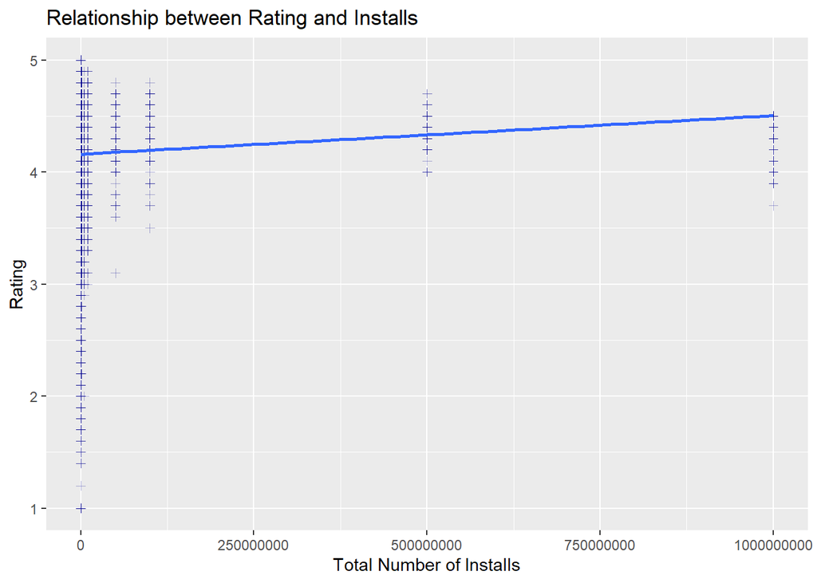

```r
ggplot(google_eda,aes(x=Installs,y=Rating)) +
  geom_point(shape = 3,alpha = 0.3,col="Darkblue")+
  geom_smooth(method = 'lm',se = FALSE)+
  xlab("Total Number of Installs") +
  ylab("Rating")+
  ggtitle("Relationship between Rating and Installs")
```

#### Finding Direction,Strength and Form of Relationship

- From scatter plot we can say that it is linear relationship and from direction of line we can say that it is positive relationship.From Correlation we can say strength of relationship is weak or no relation.

```r
cor(google_eda$Rating,google_eda$Installs)
```

```
## [1] 0.06055361
```

#### Finding Relationship In Context of Data

- According Our Dataset we know App which are having high number of Installs it is having higher App rating but from scatter plot above we can not find that strongly.
- It is confusing because some App have Higher Numer of Installs and some have smaller number of installs still both type of App are having High range of Rating.

#### Finding Variability

- From Correlation value we found their is weak relationship or no relationship between App rating and Installs, constantness is also bad across all data.
- When we talk about high App rating which is above 4 than there are both types of Apps inclded those whom have Higher number of Installs as well as smaller number of installs which does not define variability in our data.

### **(4). Data Modeling**

#### Uderstanding Hypothesis

- Our Main Hypothesis is to predict App rating based upon App Reviews and App total number of Installs OR is their any relation between Rating,Reviews and Installs variables.
- Here our Response variable is App Rating and Explanatory variables are Reviews,Installs.
- We will create two model one for Predicting Rating using Reviews and second for predicting Rating using Installs.
- By creating model our main goal to achieve that by inputing values of Reviews and Installs we should be abel to predict what will be App rating.
- In order to do modeling we wiil use linear model to predict as well as plot best fitting line.

#### **Model 1: Rating and Reviews**

#### Visualizing Relationship

- Here we would use Scatter plot to display relationship between Rating and another numerical variable.
- Rating is our Response variable we will put it on Y-axis and Reviews is our explanatory variable we will put it on X-axis.

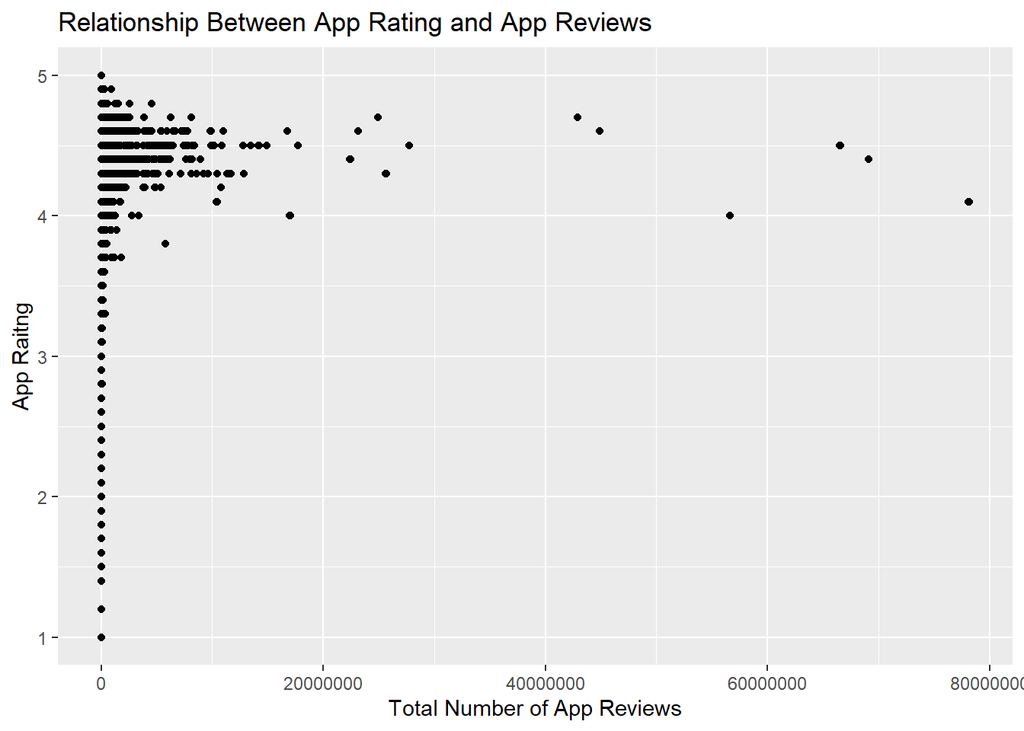

```r
google_modeling <-  google_eda

ggplot(google_modeling,aes(x=Reviews,y=Rating))+
  geom_point()+
  xlab("Total Number of App Reviews")+
  ylab("App Raitng") +
  ggtitle("Relationship Between App Rating and App Reviews")
```

#### Finding Relationship

```r
cor(google_modeling$Rating,google_modeling$Reviews)
```

```
## [1] 0.07556965
```

#### Checking Strength,Direction,Form

- strength of relation is very weak or no relation and it is positive relation with correlation value of 0.07556965.
- there are some observations in our relationship is that most of rating is between 4 to 5 so most of data points are between this two rating.

#### Creating linear Model

- linear regression is machine learning technique which is used to predict numeric value based upon another numeric value using best fitting line.
- In order to predict value using best fit line it uses function Y = b0 + b1x, here Y is our predicted value,b0 is y-intercepting value, b1 is our slope value and x is our explanatory variable.
- By putting value of Explanatory varibale into this function we can predict value for Y which is response variable.

```r
model1  <- lm(Rating ~ Reviews,data=google_modeling)
model1
```

```
##
## Call:
## lm(formula = Rating ~ Reviews, data = google_modeling)
##
## Coefficients:
##   (Intercept)        Reviews
## 4.16014089403  0.00000001248
```

```r
summary(model1)
```

```
##
## Call:
## lm(formula = Rating ~ Reviews, data = google_modeling)
##
## Residuals:
##      Min       1Q   Median       3Q      Max
## -3.16014 -0.16014  0.03981  0.33397  0.83986
##
## Coefficients:
##                   Estimate     Std. Error t value             Pr(>|t|)
## (Intercept) 4.160140894026 0.004682810971  888.38 < 0.0000000000000002 ***
## Reviews     0.000000012477 0.000000001581    7.89  0.00000000000000332 ***
## ---
## Signif. codes:  0 '***' 0.001 '**' 0.01 '*' 0.05 '.' 0.1 ' ' 1
##
## Residual standard error: 0.482 on 10838 degrees of freedom
## Multiple R-squared:  0.005711,   Adjusted R-squared:  0.005619
## F-statistic: 62.25 on 1 and 10838 DF,  p-value: 0.000000000000003318
```

- Lm model it gives us our intercept and Slope values which are two elements of best fit line for predicting response variable.
- summary function gives us summary regarding our model it gives us five number summary for our model, coefficients which gives us our Estimated Slope and intercept.
- Based upon above we can create our least squares regression line which in this case it would be **rating = 4.1601 + 0.000000012477 * Reviews** .
- The value of R square represents the proportion of variability in the response variable that is explained by the explanatory variable. For this model, 0.57% of the variability in Rating is explained by Reviews which is too less or like nothing.

#### Fitting Best line on plot

- By plotting our best fit line on plot we can see difference between Actual value and best fit line.We can plot our best fit line using geom_abline() function.
- Now using this best fit line we can predict y for any value x which is predict Rating for any value of Reviews.

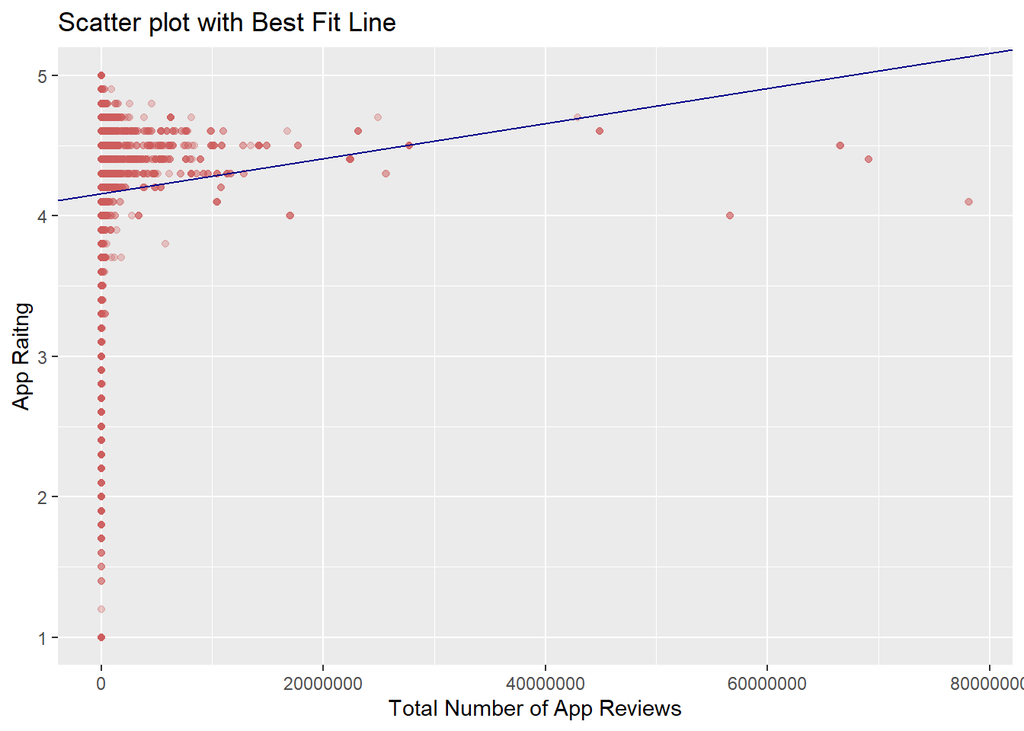

```r
ggplot(google_modeling,aes(x=Reviews,y=Rating))+
  geom_point(alpha =0.3,col="indianred") +
  geom_abline(slope =0.000000012477, intercept = 4.16014089403,col="darkblue")+
  xlab("Total Number of App Reviews")+
  ylab("App Raitng") +
  ggtitle("Scatter plot with Best Fit Line")
```